# An Exploration on Crypto Currencies

Emine Doganay, Hale Nur Kaza?esme, Hasan Palaz

November 18, 2017

The notion of cryptocurrency has entered our lives with the introduction of Bitcoin on Jan 2009. Crypto currencies are decentralized digital currencies, meaning the payment system works without a central repository or administrator. The transactions between users, creation of additional units and verification of transfers are secured by cryptography and logged into the transaction database; blockchain. In most cryptocurrencies, transactions are verified through a process called mining that requires computer processing power to find blocks of transactions and miners are rewarded with newly created crypto coins for their finds. Coins are stored in cryptocurrency wallets, which are essentially a collection of cryptographic keys. Yes, it is hard to digest the mechanics behind cryptocurrencies.

With the uncontrollable climb of Bitcoin and all these buzzwords flying around, cryptocurrencies became a hype. Part of the hype is created by the mystery caused by the enigmatic nature of cryptocurrencies and the obscurity of the workings of blockchain. The suspicion surrounding the future of cryptocurrencies were not only founded on the fear of the unknown but also on the fact that they can be lost forever from their markets due malware or data loss or even an accident as in a recent incident with an Etherium wallet that caused approximately $280m worth of Ether to be frozen.

We read the data directly from coinmarketcap.com using package rvest. The data looks like:

```
##   X.                                      Name Symbol       Market.Cap
## 1  1      BTC\n                        Bitcoin    BTC $136,059,212,772
## 2  2     ETH\n                        Ethereum    ETH  $34,970,969,557
## 3  3 BCH\n                        Bitcoin Cash    BCH  $19,970,903,735
## 4  4       XRP\n                        Ripple    XRP   $9,072,048,785
##       Price
## 1  $8150.04
## 2   $364.75
## 3  $1187.66
## 4 $0.234888
##                                                                                  Circulating.Supply
## 1                                                                                        16,694,300
## 2                                                                                        95,877,333
## 3                                                                                        16,815,338
## 4 38,622,870,411\n                        \n                        \n                            *
##     Volume..24h. X..1h X..24h  X..7d
## 1 $3,410,610,000 0.16%  2.86% 18.68%
## 2   $696,439,000 0.33%  2.33%  8.18%
## 3   $540,450,000 0.20%  1.75% -7.70%
## 4   $123,015,000 0.25%  0.81% 11.91%
```

We can see that the data contains a few unwanted characters such as new line, , $,*, spaces, %. In order to conduct analysis, we need to remove these characters.

An alternative way to retrive data is to use the JSON API at api.coinmarketcap.com which provides clean data. The data from the JSON API looks like:

```
##             id         name symbol   price_usd  price_btc 24h_volume_usd
## 1      bitcoin      Bitcoin    BTC 8148.130000 1.00000000     3391250000
## 2     ethereum     Ethereum    ETH  364.563000 0.04480590      691673000
## 3 bitcoin-cash Bitcoin Cash    BCH 1187.900000 0.14599600      536352000
## 4       ripple       Ripple    XRP    0.235216 0.00002891      121939000
##   market_cap_usd available_supply total_supply max_supply
## 1   136027326659         16694300     16694300    2.1e+07
## 2    34953328127         95877333     95877333         NA
## 3    19974939416         16815338     16815338    2.1e+07
## 4     9084717087      38622870411  99993173757    1.0e+11
##   percent_change_1h percent_change_24h percent_change_7d last_updated
## 1              0.14               2.77             18.61   1511329458
## 2              0.28               2.26              8.13   1511329452
## 3              0.01               1.78             -7.68   1511329469
## 4              0.39               0.91             12.06   1511329441
```

which is much cleaner aside from NA’s. But to demonstrate what we have learned in this class we chose to work with the data collected with rvest package and cleaned it.

```r
# Cleaning the data
# Before cleaning, "\n" in the name strings should be replaced with "-" in df_cryptocurrencies$Name column
df_cryptocurrencies$Name <- lapply(df_cryptocurrencies$Name, gsub, pattern = "\n", replacement = "-")

# In order to conduct analysis, we need to remove the unwanted characters such as \n, $,*, spaces, %.
df_cryptocurrencies[] <- lapply(df_cryptocurrencies, gsub, pattern = "\\\n|\\s|[%*$,?]", replacement = "")

# remove the first column X. (coins' ranking of coinmarketcap web site)
df_cryptocurrencies$X. <- NULL

# Update the column names short, lowercase and meaningful
names(df_cryptocurrencies) <- c("name", "symbol", "marketcap", "price", "supply", "volume", "change_1h", "change_24h", "change_7d")

# Let's see how our data frame, df_cryptocurrencies looks after cleaning process
head(df_cryptocurrencies)
```

```
##              name symbol    marketcap    price      supply     volume
## 1     BTC-Bitcoin    BTC 136313181944  8166.47    16691812 3646950000
## 2    ETH-Ethereum    ETH  35454636161   369.88    95854170  829166000
## 3 BCH-BitcoinCash    BCH  20260011438  1205.00    16813288  805053000
## 4      XRP-Ripple    XRP   9294290087 0.240642 38622892459  217092000
## 5    LTC-Litecoin    LTC   3896591147    72.26    53921758  184708000
## 6       DASH-Dash   DASH   3697907383   480.19     7700877  172060000
##   change_1h change_24h change_7d
## 1     -0.69       2.08     23.75
## 2      0.31       3.64     15.68
## 3     -0.49       2.25     -6.41
## 4      0.10       3.08     16.77
## 5     -0.32       0.24     17.93
## 6      0.94       8.90     13.33
```

For mathematical analysis variable types should be numeric.

```r
# Check type of marketcap
typeof(df_cryptocurrencies$marketcap)
```

```
## [1] "character"
```

However some are not. So we transform the type of variables except name and symbol to numeric and assign into a new data frame. And after transformation data type of marketcap becomes:

```
## [1] "double"
```

Let’s see how our data frame looks like now:

```
##              name symbol    marketcap       price      supply     volume
## 1     BTC-Bitcoin    BTC 136313181944 8166.470000    16691812 3646950000
## 2    ETH-Ethereum    ETH  35454636161  369.880000    95854170  829166000
## 3 BCH-BitcoinCash    BCH  20260011438 1205.000000    16813288  805053000
## 4      XRP-Ripple    XRP   9294290087    0.240642 38622892459  217092000
##   change_1h change_24h change_7d
## 1     -0.69       2.08     23.75
## 2      0.31       3.64     15.68
## 3     -0.49       2.25     -6.41
## 4      0.10       3.08     16.77
```

```
## [1] 912   9
```

and how many coins are there in the market?

```
## [1] 912
```

When you consider there are only 180 recognized currencies in the world this is a huge number. However not all of them are big players. Let’s draw the market share of all crypto currencies as a treemap to get a better understanding:

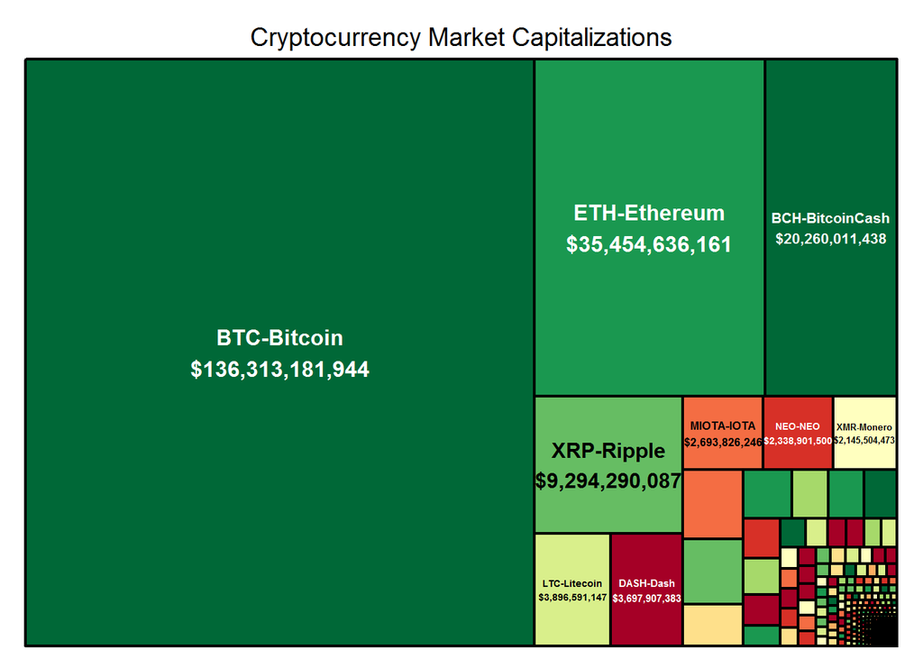

Normal currencies are dependable because they have a relatively stable standing against each other and their market only gets effected from big political or economical events. However with a decentralized non-physical currency it all works differently. With no mechanism to act on a financial policy to regulate sudden price changes, price of the crypto-currencies are literally defined in the market.  
Let’s see how big these changes can be by exploring the evolution of the market in 1 hour, 24 hours and 7 days for all crypto currencies.  
Summary of statistics and standard deviation of market change in 1 hour are as follows:

```r
summary(df_allcryptocurrencies$change_1h)
```

```
##     Min.  1st Qu.   Median     Mean  3rd Qu.     Max.     NA's
## -45.0000  -0.8000  -0.7800  -0.3650  -0.4025 237.3100       74
```

```r
sd(df_allcryptocurrencies$change_1h, na.rm=TRUE)
```

```
## [1] 10.85265
```

Summary of statistics and standard deviation of market change in 24 hours are as follows:

```r
summary(df_allcryptocurrencies$change_24h)
```

```
##     Min.  1st Qu.   Median     Mean  3rd Qu.     Max.     NA's
##  -85.400   -4.735    1.310    7.255    5.460 1495.840       33
```

```r
sd(df_allcryptocurrencies$change_24h, na.rm=TRUE)
```

```
## [1] 76.46643
```

Summary of statistics and standard deviation of market change in 7 days are as follows:

```r
summary(df_allcryptocurrencies$change_7d)
```

```
##    Min. 1st Qu.  Median    Mean 3rd Qu.    Max.    NA's
##  -94.75   -2.61   13.33   26.53   30.53 2210.01      55
```

```r
sd(df_allcryptocurrencies$change_7d, na.rm=TRUE)
```

```
## [1] 123.1535
```

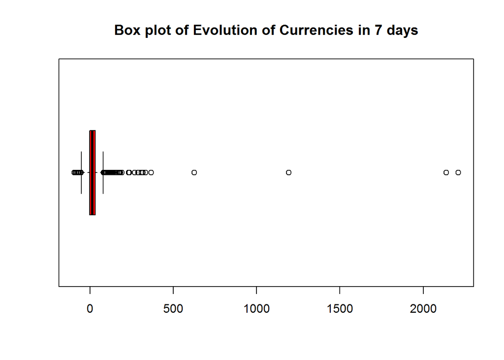

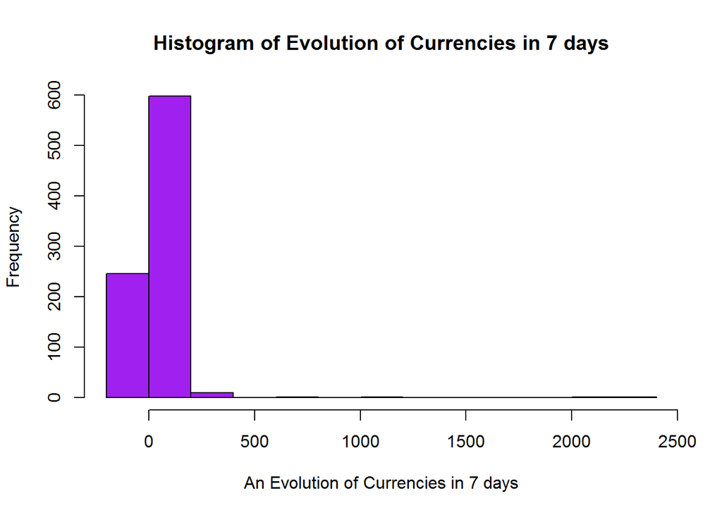

However these price changes don’t mean much without the context. Surely an $100 increase of Bitcoin (which is valued about $8000 at the time of this writing) is not the same an $100 increase of Ethereum (which is valued about $300 at the time of this writing). Let’s find all the cryptocurrencies whose value has more than doubled in 7 days:

```
##  [1] FTC-Feathercoin     DIME-Dimecoin       KRB-Karbowanec
##  [4] SUPER-SuperCoin     CAGE-CageCoin       ONX-Onix
##  [7] NYC-NewYorkCoin     CHC-ChainCoin       SIGT-Signatum
## [10] RC-RussiaCoin       XSH-SHIELD          SMC-SmartCoin
## [13] XGR-GoldReserve     BCF-BitcoinFast     TOR-Torcoin
## [16] WYV-Wyvern          CHESS-ChessCoin     CORG-CorgiCoin
## [19] ACP-AnarchistsPrime XRC-Rawcoin         ULA-Ulatech
## 912 Levels: -Money 020-020LondonCoin 1337-1337 2GIVE-2GIVE ... ZYD-Zayedcoin
```

and let’s find all the cryptocurrencies which lost more than 25% of its value in 7 days:

```
##  [1] B3-B3Coin        BDL-Bitdeal      RUP-Rupee        XGOX-XGOX
##  [5] EQT-EquiTrader   ADC-AudioCoin    ZEIT-Zeitcoin    BTCZ-BitcoinZ
##  [9] FIMK-FIMKrypto   XCN-Cryptonite   MAO-MaoZedong    INSN-InsaneCoin
## [13] PND-Pandacoin    XIOS-Xios        EMB-EmberCoin    CRM-Cream
## [17] BLAS-BlakeStar   KLC-KiloCoin     ENT-Eternity     808-808Coin
## [21] ICON-Iconic      ERY-Eryllium     PLACO-PlayerCoin NANOX-Project-X
## [25] FAL-Falcoin
## 912 Levels: -Money 020-020LondonCoin 1337-1337 2GIVE-2GIVE ... ZYD-Zayedcoin
```

By the tree chart above we know that Bitcoin is the dominant player in the market.  
The total market capitalization currently is:

```
## [1] "$233,308,594,682"
```

and Bitcoin’s share is:

```
## [1] "0.5842613%"
```

Even though Bitcoin is sharing the market with more and more crypto currencies each day, it remains the biggest player.

Let’s focus on top 10 currrencies by market cap.

```
##               name symbol    marketcap       price      supply     volume
## 1      BTC-Bitcoin    BTC 136313181944 8166.470000    16691812 3646950000
## 2     ETH-Ethereum    ETH  35454636161  369.880000    95854170  829166000
## 3  BCH-BitcoinCash    BCH  20260011438 1205.000000    16813288  805053000
## 4       XRP-Ripple    XRP   9294290087    0.240642 38622892459  217092000
## 5     LTC-Litecoin    LTC   3896591147   72.260000    53921758  184708000
## 6        DASH-Dash   DASH   3697907383  480.190000     7700877  172060000
## 7       MIOTA-IOTA  MIOTA   2693826246    0.969166  2779530283   97824400
## 8          NEO-NEO    NEO   2338901500   35.980000    65000000  253687000
## 9       XMR-Monero    XMR   2145504473  139.520000    15377976   63950100
## 10         XEM-NEM    XEM   1898622000    0.210958  8999999999   14283400
##    change_1h change_24h change_7d             formatted_market_cap
## 1      -0.69       2.08     23.75    BTC-Bitcoin\n$136,313,181,944
## 2       0.31       3.64     15.68    ETH-Ethereum\n$35,454,636,161
## 3      -0.49       2.25     -6.41 BCH-BitcoinCash\n$20,260,011,438
```

[output cut: 18 more lines]

Total market share of the top 10 coins is:

```
## [1] "93.43568%"
```

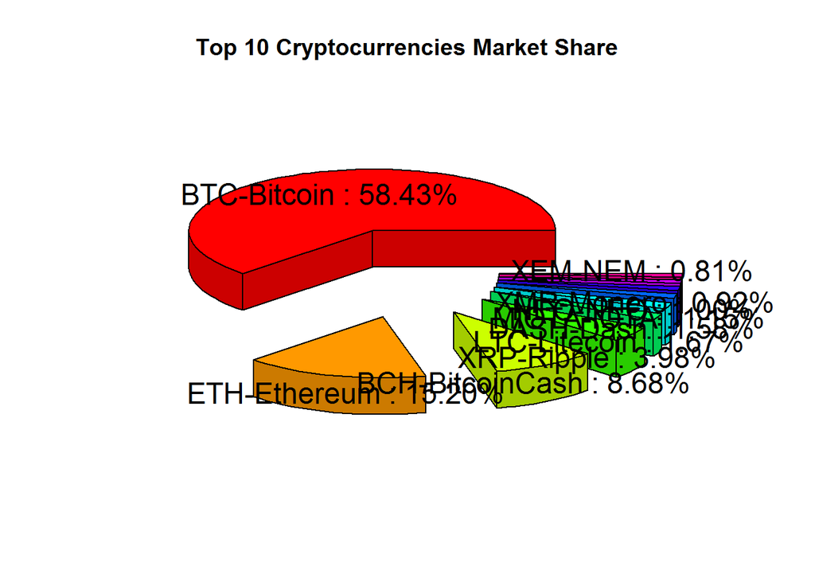

Since we are focusing on the top currencies we gather historical data from CoinMarketCap web site as the top curriencies go way back than some other small currencies. HTML data is converted into a dataframe because there is no API to get the historic data of cryptocurrencies. We will study the daily evolution of top 5 cryptocurrencies:

```
##              name symbol
## 1     BTC-Bitcoin    BTC
## 2    ETH-Ethereum    ETH
## 3 BCH-BitcoinCash    BCH
## 4      XRP-Ripple    XRP
## 5    LTC-Litecoin    LTC
```

We import the historical data for these currencies.

Bitcoin

```
##       Date                 Open             High              Low
##  Min.   :2013-04-28   Min.   :  68.5   Min.   :  74.56   Min.   :  65.53
##  1st Qu.:2014-06-19   1st Qu.: 265.5   1st Qu.: 270.83   1st Qu.: 260.95
##  Median :2015-08-10   Median : 454.9   Median : 460.15   Median : 446.11
##  Mean   :2015-08-10   Mean   : 875.6   Mean   : 901.99   Mean   : 852.00
##  3rd Qu.:2016-09-30   3rd Qu.: 758.7   3rd Qu.: 774.70   3rd Qu.: 738.92
##  Max.   :2017-11-21   Max.   :8205.7   Max.   :8348.66   Max.   :7949.36
##
##      Close             Volume            Market.Cap
##  Min.   :  68.43   Min.   :2.858e+06   Min.   :7.793e+08
##  1st Qu.: 265.66   1st Qu.:2.181e+07   1st Qu.:3.774e+09
##  Median : 454.99   Median :5.067e+07   Median :6.600e+09
##  Mean   : 880.30   Mean   :3.211e+08   Mean   :1.362e+10
##  3rd Qu.: 758.70   3rd Qu.:1.298e+08   3rd Qu.:1.074e+10
##  Max.   :8200.64   Max.   :8.957e+09   Max.   :1.370e+11
##                    NA's   :243
##    Percentage
##  Min.   :-0.429680
##  1st Qu.:-0.018626
##  Median :-0.001956
##  Mean   :-0.003381
##  3rd Qu.: 0.011286
##  Max.   : 0.233712
##
```

Ethereum

```
##       Date                 Open               High
##  Min.   :2015-08-07   Min.   :  0.4316   Min.   :  0.483
##  1st Qu.:2016-03-03   1st Qu.:  7.1350   1st Qu.:  7.357
##  Median :2016-09-28   Median : 11.4500   Median : 11.825
##  Mean   :2016-09-28   Mean   : 73.0548   Mean   : 76.140
##  3rd Qu.:2017-04-25   3rd Qu.: 53.0425   3rd Qu.: 54.867
##  Max.   :2017-11-21   Max.   :397.5900   Max.   :414.760
##
##       Low               Close              Volume
##  Min.   :  0.4209   Min.   :  0.4348   Min.   :1.021e+05
##  1st Qu.:  6.7575   1st Qu.:  7.1700   1st Qu.:5.850e+06
##  Median : 11.1750   Median : 11.4850   Median :1.671e+07
##  Mean   : 70.0287   Mean   : 73.4710   Mean   :2.187e+08
##  3rd Qu.: 51.5400   3rd Qu.: 53.1250   3rd Qu.:1.691e+08
##  Max.   :383.4700   Max.   :401.4900   Max.   :2.883e+09
##
##    Market.Cap          Percentage
##  Min.   :3.197e+07   Min.   :-0.510344
##  1st Qu.:5.880e+08   1st Qu.:-0.034190
##  Median :9.600e+08   Median : 0.001083
##  Mean   :6.806e+09   Mean   :-0.009241
##  3rd Qu.:4.810e+09   3rd Qu.: 0.025597
##  Max.   :3.676e+10   Max.   : 0.728042
##  NA's   :1
```

BitcoinCash

```
##       Date                 Open             High             Low
##  Min.   :2017-07-23   Min.   : 212.2   Min.   : 223.7   Min.   : 201.0
##  1st Qu.:2017-08-22   1st Qu.: 343.4   1st Qu.: 371.7   1st Qu.: 316.5
##  Median :2017-09-21   Median : 438.6   Median : 471.8   Median : 414.4
##  Mean   :2017-09-21   Mean   : 517.5   Mean   : 577.2   Mean   : 476.1
##  3rd Qu.:2017-10-21   3rd Qu.: 601.1   3rd Qu.: 642.5   3rd Qu.: 569.1
##  Max.   :2017-11-21   Max.   :1381.8   Max.   :2477.7   Max.   :1215.6
##
##      Close            Volume            Market.Cap
##  Min.   : 213.2   Min.   :8.501e+04   Min.   :3.497e+09
##  1st Qu.: 343.0   1st Qu.:1.645e+08   1st Qu.:5.664e+09
##  Median : 439.6   Median :2.993e+08   Median :7.396e+09
##  Mean   : 521.9   Mean   :7.065e+08   Mean   :8.784e+09
##  3rd Qu.: 606.2   3rd Qu.:7.658e+08   3rd Qu.:1.027e+10
##  Max.   :1388.9   Max.   :8.371e+09   Max.   :2.321e+10
##                                       NA's   :10
##    Percentage
##  Min.   :-0.539691
##  1st Qu.:-0.052810
##  Median : 0.004763
##  Mean   :-0.016847
##  3rd Qu.: 0.048317
##  Max.   : 0.359841
##
```

Ripple

```
##       Date                 Open               High
##  Min.   :2013-08-04   Min.   :0.002809   Min.   :0.003082
##  1st Qu.:2014-08-31   1st Qu.:0.006023   1st Qu.:0.006126
##  Median :2015-09-28   Median :0.007760   Median :0.007924
##  Mean   :2015-09-28   Mean   :0.036805   Mean   :0.038760
##  3rd Qu.:2016-10-24   3rd Qu.:0.014436   3rd Qu.:0.015033
##  Max.   :2017-11-21   Max.   :0.394931   Max.   :0.435170
##
##       Low               Close              Volume
##  Min.   :0.002802   Min.   :0.002810   Min.   :8.316e+03
##  1st Qu.:0.005933   1st Qu.:0.006027   1st Qu.:2.829e+05
##  Median :0.007543   Median :0.007772   Median :6.692e+05
##  Mean   :0.034998   Mean   :0.036947   Mean   :2.950e+07
##  3rd Qu.:0.014032   3rd Qu.:0.014435   3rd Qu.:2.307e+06
##  Max.   :0.332222   Max.   :0.394132   Max.   :1.770e+09
##                                        NA's   :145
##    Market.Cap          Percentage
##  Min.   :2.196e+07   Min.   :-1.793669
##  1st Qu.:1.431e+08   1st Qu.:-0.020750
##  Median :2.341e+08   Median : 0.002604
##  Mean   :1.302e+09   Mean   :-0.005443
##  3rd Qu.:3.157e+08   3rd Qu.: 0.020879
##  Max.   :1.513e+10   Max.   : 0.460047
##
```

Litecoin

```
##       Date                 Open            High            Low
##  Min.   :2013-04-28   Min.   : 1.15   Min.   : 1.34   Min.   : 1.11
##  1st Qu.:2014-06-19   1st Qu.: 3.09   1st Qu.: 3.14   1st Qu.: 3.02
##  Median :2015-08-10   Median : 3.86   Median : 3.92   Median : 3.81
##  Mean   :2015-08-10   Mean   :10.75   Mean   :11.23   Mean   :10.25
##  3rd Qu.:2016-09-30   3rd Qu.:10.30   3rd Qu.:10.55   3rd Qu.: 9.80
##  Max.   :2017-11-21   Max.   :85.83   Max.   :92.07   Max.   :75.59
##
##      Close           Volume            Market.Cap
##  Min.   : 1.16   Min.   :4.817e+05   Min.   :3.794e+07
##  1st Qu.: 3.08   1st Qu.:1.755e+06   1st Qu.:1.205e+08
##  Median : 3.86   Median :3.162e+06   Median :1.760e+08
##  Mean   :10.79   Mean   :5.047e+07   Mean   :4.698e+08
##  3rd Qu.:10.31   3rd Qu.:9.418e+06   3rd Qu.:2.959e+08
##  Max.   :86.04   Max.   :1.731e+09   Max.   :4.527e+09
##                  NA's   :243
##    Percentage
##  Min.   :-1.290954
##  1st Qu.:-0.016491
##  Median : 0.000000
##  Mean   :-0.004071
##  3rd Qu.: 0.017422
##  Max.   : 0.401857
##
```

Let’s examine the percentage of price changes for Bitcoin:

```r
summary(df_bitcoin$Percentage)
```

```
##      Min.   1st Qu.    Median      Mean   3rd Qu.      Max.
## -0.429680 -0.018626 -0.001956 -0.003381  0.011286  0.233712
```

```r
sd(df_bitcoin$Percentage)
```

```
## [1] 0.04312892
```

Bitcoin is highly volatile; it has gained up to 23% or lost up to 43% in only one day.

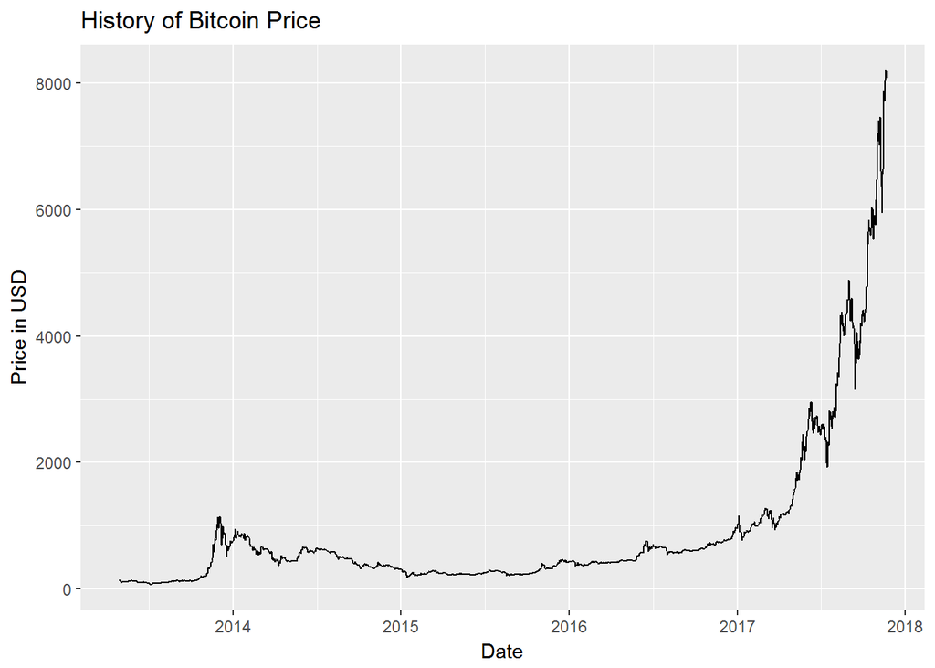

Let’s examine the percentage of price changes for Ethereum:

```r
summary(df_ethereum$Percentage)
```

```
##      Min.   1st Qu.    Median      Mean   3rd Qu.      Max.
## -0.510344 -0.034190  0.001083 -0.009241  0.025597  0.728042
```

```r
sd(df_ethereum$Percentage)
```

```
## [1] 0.08004012
```

Ethereum is also extremely volatile for a currency; it has gained up to 72% or lost up to 51% in only one day.

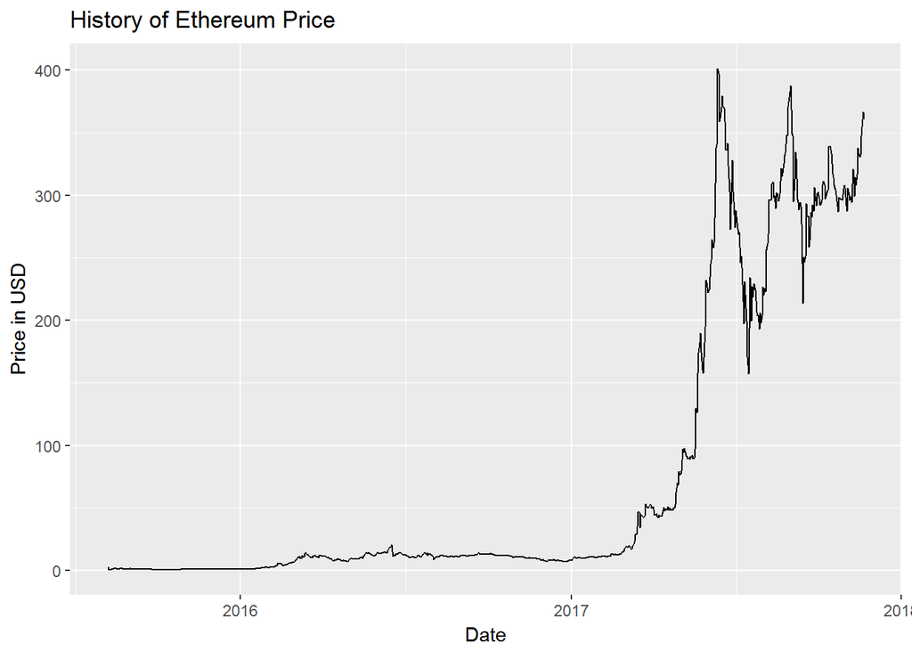

Correlation between cryptocurrencies’ closing prices gives us an idea if they behave similarly to normal currencies or if people treat them basically being the same since they are not affiliated with anything but code chunks and blockchains.

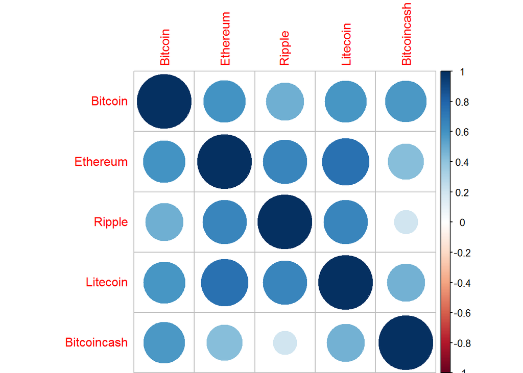

We can see that, at least the top five cryptocurrencies are correlated. This means that a negative news about one might affect the others negatively even if not at the same magnitude.

Wait a second! Are we jumping to conclusions here? Remember, these all sail at different price levels so we need some sort of normalization. Currently we trying to correlate a data like this:

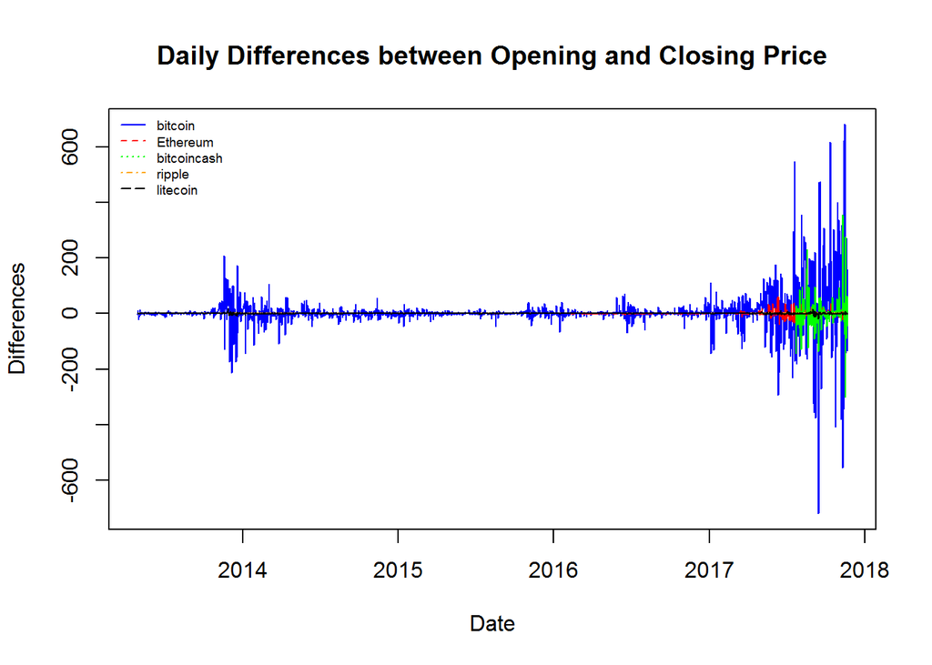

You can’t even see Ripple and Litecoin in the graph. But after normalizing by turning them into percentage changes the data we are trying to correlate becomes like this:

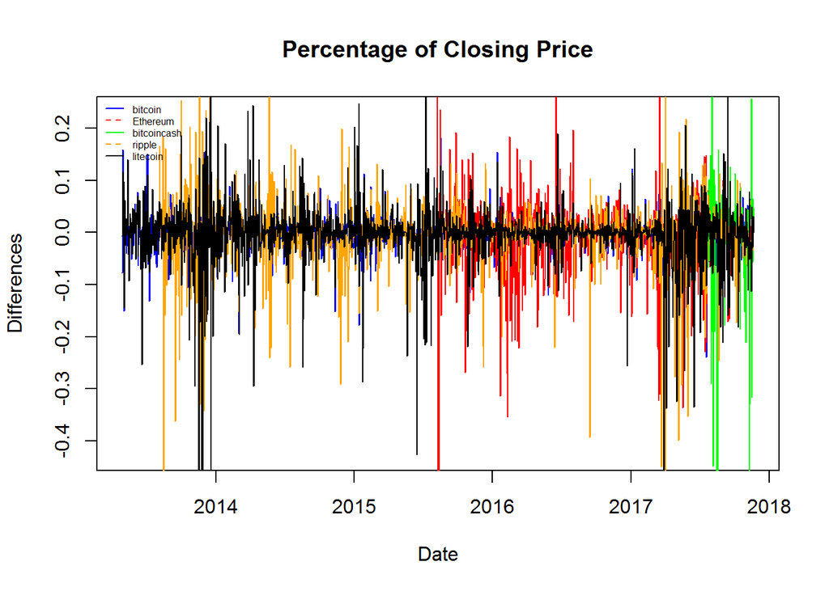

Let’s look at the correlation between the percentage changes:

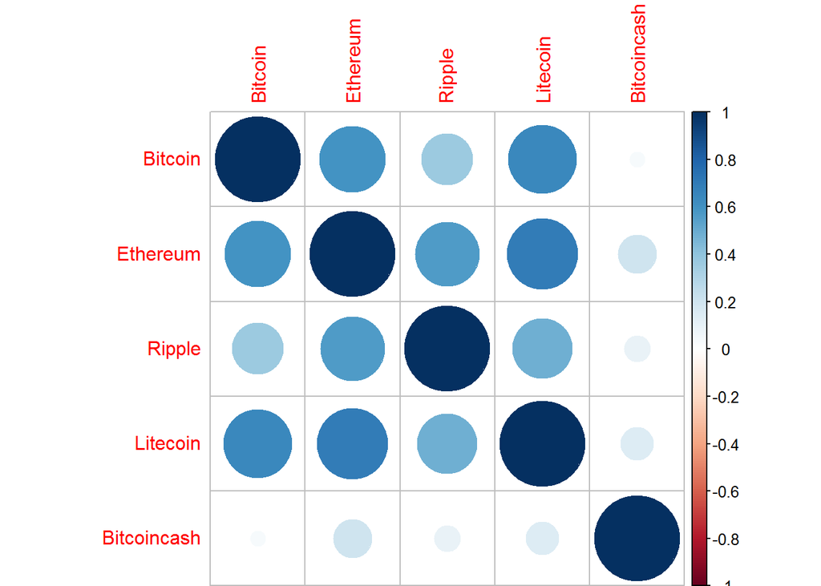

The correlations have weakened a little bit and BitcoinCash seems to be acting independently. So, good news! You might still bet on some crypto currencies while shorting others and make money on both exchanges! Obligatory Warning: The market is highly volatile so it can be too risky.

Since Bitcoin was first to market, has limited supply and unregulated a natural question to ask is “how similar it is to gold”? Correlation with the well known asset and the gold of the digital world is:

```
## [1] 0.1037629
```

It can be seen that the correlation is nothing of importance. Bitcoin is only a tiny fraction of gold in terms of market capitalization and gold’s physical vs Bitcoin’s digital makes them two separate markets even though you can mine Bitcoins, too.

We have talked about the speculative aspect of crypto currencies, let’s see if our intuition was correct on this one. In here, we try to define the correlation between bitcoin and google search by comparing historical price datas to Google search trend of Bitcoin.

```
## [1] 0.9228585
```

Yes, they are extremely correlated! This could mean that the price of crypto currencies can be affected from negative or positive publicity and/or vice versa; a huge change in prices might spark interest and sequentially people might be searching for more information on them.

Plot Currencis Change over time

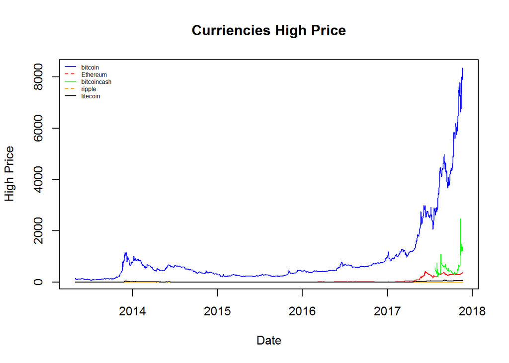

Linear regression analysis between bitcoin high price and Ethereum high price for last 30 days.

[output not shown]

[figure not shown]

```
##
## Call:
## lm(formula = Close ~ High, data = df_bitcoin)
##
## Residuals:
##     Min      1Q  Median      3Q     Max
## -660.21   -2.91    2.38    9.44  184.43
##
## Coefficients:
##              Estimate Std. Error  t value Pr(>|t|)
## (Intercept) 3.3411415  1.3357430    2.501   0.0125 *
## High        0.9722529  0.0008459 1149.388   <2e-16 ***
## ---
## Signif. codes:  0 '***' 0.001 '**' 0.01 '*' 0.05 '.' 0.1 ' ' 1
##
## Residual standard error: 44.79 on 1667 degrees of freedom
## Multiple R-squared:  0.9987, Adjusted R-squared:  0.9987
## F-statistic: 1.321e+06 on 1 and 1667 DF,  p-value: < 2.2e-16
```

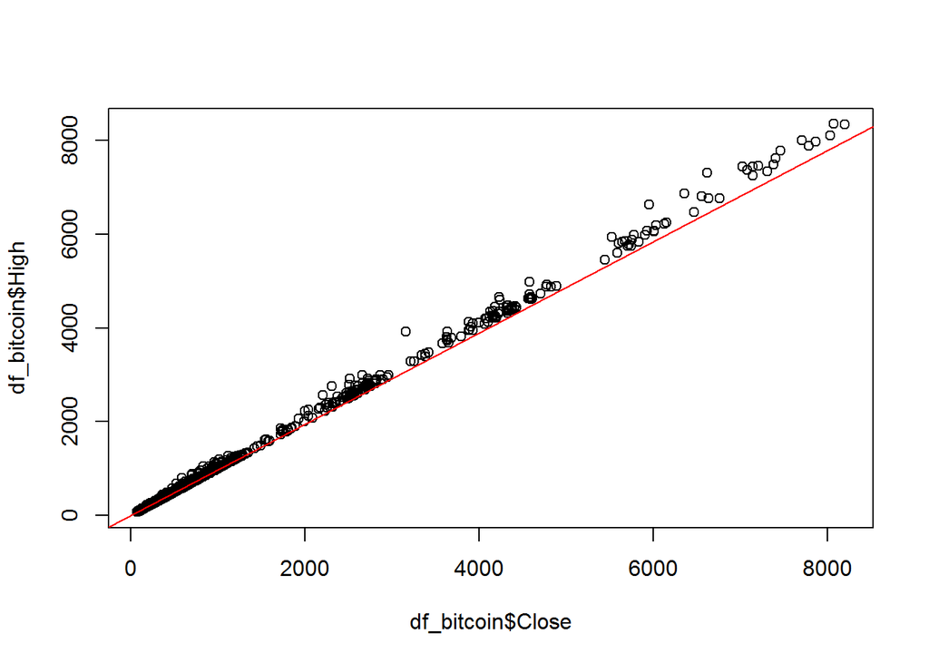

```
##
## Call:
## lm(formula = Volume ~ Market.Cap + High + Percentage, data = df_bitcoin)
##
## Residuals:
##        Min         1Q     Median         3Q        Max
## -1.250e+09 -9.321e+07  1.872e+07  9.518e+07  5.712e+09
##
## Coefficients:
##               Estimate Std. Error t value Pr(>|t|)
## (Intercept) -2.395e+08  1.164e+07 -20.567   <2e-16 ***
## Market.Cap  -5.834e-02  6.939e-03  -8.408   <2e-16 ***
## High         1.444e+06  1.123e+05  12.862   <2e-16 ***
## Percentage  -3.951e+08  2.147e+08  -1.840    0.066 .
## ---
## Signif. codes:  0 '***' 0.001 '**' 0.01 '*' 0.05 '.' 0.1 ' ' 1
##
## Residual standard error: 298100000 on 1422 degrees of freedom
##   (243 observations deleted due to missingness)
## Multiple R-squared:  0.843,  Adjusted R-squared:  0.8427
## F-statistic:  2545 on 3 and 1422 DF,  p-value: < 2.2e-16
```

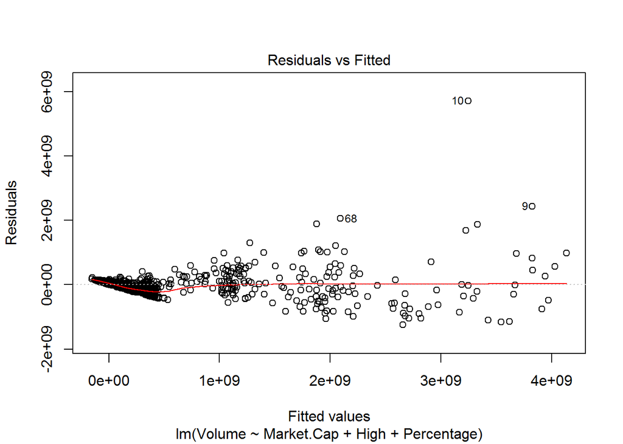